# Risk Factor Analysis

## Outcome Variable

**Outcome Variable:** y_rate_len

## Predictor Variables

**Intervention Variable:** exclfeed36

**Adjustment Set:**

- arm
- sex
- brthmon
- W_mage
- meducyrs
- feducyrs
- hhwealth_quart
- hfoodsec
- W_mhtcm
- W_mwtkg
- W_mbmi
- vagbrth
- W_birthwt
- W_birthlen
- W_nrooms
- month
- W_parity
- impfloor
- impsan
- safeh20
- delta_W_mage
- delta_meducyrs
- delta_feducyrs
- delta_hhwealth_quart
- delta_hfoodsec
- delta_W_mhtcm
- delta_W_mwtkg
- delta_W_mbmi
- delta_vagbrth
- delta_W_birthwt
- delta_W_birthlen
- delta_W_nrooms
- delta_month
- delta_W_parity
- delta_impfloor
- delta_impsan
- delta_safeh20

## Stratifying Variables

The analysis was stratified on these variable(s):

- agecat
- studyid
- country

## Data Summary

| agecat | studyid | country | exclfeed36 | n_cell | n |
| --- | --- | --- | --- | --- | --- |
| 0-3 months | CMC-V-BCS-2002 | INDIA | 1 | 2 | 2 |
| 0-3 months | CMC-V-BCS-2002 | INDIA | 0 | 0 | 2 |
| 0-3 months | EE | PAKISTAN | 1 | 2 | 6 |
| 0-3 months | EE | PAKISTAN | 0 | 4 | 6 |
| 0-3 months | GMS-Nepal | NEPAL | 1 | 372 | 465 |
| 0-3 months | GMS-Nepal | NEPAL | 0 | 93 | 465 |
| 0-3 months | IRC | INDIA | 1 | 0 | 4 |
| 0-3 months | IRC | INDIA | 0 | 4 | 4 |
| 0-3 months | JiVitA-3 | BANGLADESH | 1 | 7572 | 9726 |
| 0-3 months | JiVitA-3 | BANGLADESH | 0 | 2154 | 9726 |
| 0-3 months | JiVitA-4 | BANGLADESH | 1 | 1399 | 1685 |
| 0-3 months | JiVitA-4 | BANGLADESH | 0 | 286 | 1685 |
| 0-3 months | Keneba | GAMBIA | 1 | 326 | 1116 |
| 0-3 months | Keneba | GAMBIA | 0 | 790 | 1116 |
| 0-3 months | MAL-ED | BANGLADESH | 1 | 32 | 242 |
| 0-3 months | MAL-ED | BANGLADESH | 0 | 210 | 242 |
| 0-3 months | MAL-ED | BRAZIL | 1 | 8 | 167 |
| 0-3 months | MAL-ED | BRAZIL | 0 | 159 | 167 |
| 0-3 months | MAL-ED | INDIA | 1 | 4 | 181 |
| 0-3 months | MAL-ED | INDIA | 0 | 177 | 181 |
| 0-3 months | MAL-ED | NEPAL | 1 | 4 | 154 |
| 0-3 months | MAL-ED | NEPAL | 0 | 150 | 154 |
| 0-3 months | MAL-ED | PERU | 1 | 5 | 263 |
| 0-3 months | MAL-ED | PERU | 0 | 258 | 263 |
| 0-3 months | MAL-ED | SOUTH AFRICA | 1 | 0 | 209 |
| 0-3 months | MAL-ED | SOUTH AFRICA | 0 | 209 | 209 |
| 0-3 months | MAL-ED | TANZANIA, UNITED REPUBLIC OF | 1 | 3 | 223 |
| 0-3 months | MAL-ED | TANZANIA, UNITED REPUBLIC OF | 0 | 220 | 223 |
| 0-3 months | PROVIDE | BANGLADESH | 1 | 161 | 634 |
| 0-3 months | PROVIDE | BANGLADESH | 0 | 473 | 634 |

[output cut: 214 more lines]

The following strata were considered:

- agecat: 0-3 months, studyid: CMC-V-BCS-2002, country: INDIA
- agecat: 0-3 months, studyid: EE, country: PAKISTAN
- agecat: 0-3 months, studyid: GMS-Nepal, country: NEPAL
- agecat: 0-3 months, studyid: IRC, country: INDIA
- agecat: 0-3 months, studyid: JiVitA-3, country: BANGLADESH
- agecat: 0-3 months, studyid: JiVitA-4, country: BANGLADESH
- agecat: 0-3 months, studyid: Keneba, country: GAMBIA
- agecat: 0-3 months, studyid: MAL-ED, country: BANGLADESH
- agecat: 0-3 months, studyid: MAL-ED, country: BRAZIL
- agecat: 0-3 months, studyid: MAL-ED, country: INDIA
- agecat: 0-3 months, studyid: MAL-ED, country: NEPAL
- agecat: 0-3 months, studyid: MAL-ED, country: PERU
- agecat: 0-3 months, studyid: MAL-ED, country: SOUTH AFRICA
- agecat: 0-3 months, studyid: MAL-ED, country: TANZANIA, UNITED REPUBLIC OF
- agecat: 0-3 months, studyid: PROVIDE, country: BANGLADESH
- agecat: 12-15 months, studyid: CMC-V-BCS-2002, country: INDIA
- agecat: 12-15 months, studyid: EE, country: PAKISTAN
- agecat: 12-15 months, studyid: GMS-Nepal, country: NEPAL
- agecat: 12-15 months, studyid: IRC, country: INDIA
- agecat: 12-15 months, studyid: JiVitA-4, country: BANGLADESH
- agecat: 12-15 months, studyid: Keneba, country: GAMBIA
- agecat: 12-15 months, studyid: LCNI-5, country: MALAWI
- agecat: 12-15 months, studyid: MAL-ED, country: BANGLADESH
- agecat: 12-15 months, studyid: MAL-ED, country: BRAZIL
- agecat: 12-15 months, studyid: MAL-ED, country: INDIA
- agecat: 12-15 months, studyid: MAL-ED, country: NEPAL
- agecat: 12-15 months, studyid: MAL-ED, country: PERU
- agecat: 12-15 months, studyid: MAL-ED, country: SOUTH AFRICA
- agecat: 12-15 months, studyid: MAL-ED, country: TANZANIA, UNITED REPUBLIC OF
- agecat: 12-15 months, studyid: PROVIDE, country: BANGLADESH
- agecat: 12-15 months, studyid: SAS-FoodSuppl, country: INDIA
- agecat: 15-18 months, studyid: CMC-V-BCS-2002, country: INDIA
- agecat: 15-18 months, studyid: EE, country: PAKISTAN
- agecat: 15-18 months, studyid: GMS-Nepal, country: NEPAL
- agecat: 15-18 months, studyid: IRC, country: INDIA
- agecat: 15-18 months, studyid: JiVitA-4, country: BANGLADESH
- agecat: 15-18 months, studyid: Keneba, country: GAMBIA
- agecat: 15-18 months, studyid: LCNI-5, country: MALAWI
- agecat: 15-18 months, studyid: MAL-ED, country: BANGLADESH
- agecat: 15-18 months, studyid: MAL-ED, country: BRAZIL
- agecat: 15-18 months, studyid: MAL-ED, country: INDIA
- agecat: 15-18 months, studyid: MAL-ED, country: NEPAL
- agecat: 15-18 months, studyid: MAL-ED, country: PERU
- agecat: 15-18 months, studyid: MAL-ED, country: SOUTH AFRICA
- agecat: 15-18 months, studyid: MAL-ED, country: TANZANIA, UNITED REPUBLIC OF
- agecat: 15-18 months, studyid: PROVIDE, country: BANGLADESH
- agecat: 15-18 months, studyid: SAS-FoodSuppl, country: INDIA
- agecat: 18-21 months, studyid: CMC-V-BCS-2002, country: INDIA
- agecat: 18-21 months, studyid: EE, country: PAKISTAN
- agecat: 18-21 months, studyid: GMS-Nepal, country: NEPAL
- agecat: 18-21 months, studyid: IRC, country: INDIA
- agecat: 18-21 months, studyid: Keneba, country: GAMBIA
- agecat: 18-21 months, studyid: LCNI-5, country: MALAWI
- agecat: 18-21 months, studyid: MAL-ED, country: BANGLADESH
- agecat: 18-21 months, studyid: MAL-ED, country: BRAZIL
- agecat: 18-21 months, studyid: MAL-ED, country: INDIA
- agecat: 18-21 months, studyid: MAL-ED, country: NEPAL
- agecat: 18-21 months, studyid: MAL-ED, country: PERU
- agecat: 18-21 months, studyid: MAL-ED, country: SOUTH AFRICA
- agecat: 18-21 months, studyid: MAL-ED, country: TANZANIA, UNITED REPUBLIC OF
- agecat: 18-21 months, studyid: PROVIDE, country: BANGLADESH
- agecat: 21-24 months, studyid: CMC-V-BCS-2002, country: INDIA
- agecat: 21-24 months, studyid: EE, country: PAKISTAN
- agecat: 21-24 months, studyid: GMS-Nepal, country: NEPAL
- agecat: 21-24 months, studyid: IRC, country: INDIA
- agecat: 21-24 months, studyid: Keneba, country: GAMBIA
- agecat: 21-24 months, studyid: LCNI-5, country: MALAWI
- agecat: 21-24 months, studyid: MAL-ED, country: BANGLADESH
- agecat: 21-24 months, studyid: MAL-ED, country: BRAZIL
- agecat: 21-24 months, studyid: MAL-ED, country: INDIA
- agecat: 21-24 months, studyid: MAL-ED, country: NEPAL
- agecat: 21-24 months, studyid: MAL-ED, country: PERU
- agecat: 21-24 months, studyid: MAL-ED, country: SOUTH AFRICA
- agecat: 21-24 months, studyid: MAL-ED, country: TANZANIA, UNITED REPUBLIC OF
- agecat: 21-24 months, studyid: PROVIDE, country: BANGLADESH
- agecat: 3-6 months, studyid: CMC-V-BCS-2002, country: INDIA
- agecat: 3-6 months, studyid: EE, country: PAKISTAN
- agecat: 3-6 months, studyid: GMS-Nepal, country: NEPAL
- agecat: 3-6 months, studyid: IRC, country: INDIA
- agecat: 3-6 months, studyid: JiVitA-3, country: BANGLADESH
- agecat: 3-6 months, studyid: JiVitA-4, country: BANGLADESH
- agecat: 3-6 months, studyid: Keneba, country: GAMBIA
- agecat: 3-6 months, studyid: MAL-ED, country: BANGLADESH
- agecat: 3-6 months, studyid: MAL-ED, country: BRAZIL
- agecat: 3-6 months, studyid: MAL-ED, country: INDIA
- agecat: 3-6 months, studyid: MAL-ED, country: NEPAL
- agecat: 3-6 months, studyid: MAL-ED, country: PERU
- agecat: 3-6 months, studyid: MAL-ED, country: SOUTH AFRICA
- agecat: 3-6 months, studyid: MAL-ED, country: TANZANIA, UNITED REPUBLIC OF
- agecat: 3-6 months, studyid: PROVIDE, country: BANGLADESH
- agecat: 6-9 months, studyid: CMC-V-BCS-2002, country: INDIA
- agecat: 6-9 months, studyid: EE, country: PAKISTAN
- agecat: 6-9 months, studyid: GMS-Nepal, country: NEPAL
- agecat: 6-9 months, studyid: IRC, country: INDIA
- agecat: 6-9 months, studyid: JiVitA-4, country: BANGLADESH
- agecat: 6-9 months, studyid: Keneba, country: GAMBIA
- agecat: 6-9 months, studyid: LCNI-5, country: MALAWI
- agecat: 6-9 months, studyid: MAL-ED, country: BANGLADESH
- agecat: 6-9 months, studyid: MAL-ED, country: BRAZIL
- agecat: 6-9 months, studyid: MAL-ED, country: INDIA
- agecat: 6-9 months, studyid: MAL-ED, country: NEPAL
- agecat: 6-9 months, studyid: MAL-ED, country: PERU
- agecat: 6-9 months, studyid: MAL-ED, country: SOUTH AFRICA
- agecat: 6-9 months, studyid: MAL-ED, country: TANZANIA, UNITED REPUBLIC OF
- agecat: 6-9 months, studyid: PROVIDE, country: BANGLADESH
- agecat: 6-9 months, studyid: SAS-FoodSuppl, country: INDIA
- agecat: 9-12 months, studyid: CMC-V-BCS-2002, country: INDIA
- agecat: 9-12 months, studyid: EE, country: PAKISTAN
- agecat: 9-12 months, studyid: GMS-Nepal, country: NEPAL
- agecat: 9-12 months, studyid: IRC, country: INDIA
- agecat: 9-12 months, studyid: JiVitA-4, country: BANGLADESH
- agecat: 9-12 months, studyid: Keneba, country: GAMBIA
- agecat: 9-12 months, studyid: LCNI-5, country: MALAWI
- agecat: 9-12 months, studyid: MAL-ED, country: BANGLADESH
- agecat: 9-12 months, studyid: MAL-ED, country: BRAZIL
- agecat: 9-12 months, studyid: MAL-ED, country: INDIA
- agecat: 9-12 months, studyid: MAL-ED, country: NEPAL
- agecat: 9-12 months, studyid: MAL-ED, country: PERU
- agecat: 9-12 months, studyid: MAL-ED, country: SOUTH AFRICA
- agecat: 9-12 months, studyid: MAL-ED, country: TANZANIA, UNITED REPUBLIC OF
- agecat: 9-12 months, studyid: PROVIDE, country: BANGLADESH
- agecat: 9-12 months, studyid: SAS-FoodSuppl, country: INDIA

### Dropped Strata

Some strata were dropped due to rare outcomes:

- agecat: 0-3 months, studyid: CMC-V-BCS-2002, country: INDIA
- agecat: 0-3 months, studyid: EE, country: PAKISTAN
- agecat: 0-3 months, studyid: IRC, country: INDIA
- agecat: 0-3 months, studyid: MAL-ED, country: INDIA
- agecat: 0-3 months, studyid: MAL-ED, country: NEPAL
- agecat: 0-3 months, studyid: MAL-ED, country: SOUTH AFRICA
- agecat: 0-3 months, studyid: MAL-ED, country: TANZANIA, UNITED REPUBLIC OF
- agecat: 3-6 months, studyid: CMC-V-BCS-2002, country: INDIA
- agecat: 3-6 months, studyid: EE, country: PAKISTAN
- agecat: 3-6 months, studyid: IRC, country: INDIA
- agecat: 3-6 months, studyid: MAL-ED, country: NEPAL
- agecat: 3-6 months, studyid: MAL-ED, country: SOUTH AFRICA
- agecat: 3-6 months, studyid: MAL-ED, country: TANZANIA, UNITED REPUBLIC OF
- agecat: 6-9 months, studyid: CMC-V-BCS-2002, country: INDIA
- agecat: 6-9 months, studyid: EE, country: PAKISTAN
- agecat: 6-9 months, studyid: IRC, country: INDIA
- agecat: 6-9 months, studyid: MAL-ED, country: NEPAL
- agecat: 6-9 months, studyid: MAL-ED, country: SOUTH AFRICA
- agecat: 6-9 months, studyid: MAL-ED, country: TANZANIA, UNITED REPUBLIC OF
- agecat: 6-9 months, studyid: SAS-FoodSuppl, country: INDIA
- agecat: 9-12 months, studyid: CMC-V-BCS-2002, country: INDIA
- agecat: 9-12 months, studyid: EE, country: PAKISTAN
- agecat: 9-12 months, studyid: IRC, country: INDIA
- agecat: 9-12 months, studyid: MAL-ED, country: NEPAL
- agecat: 9-12 months, studyid: MAL-ED, country: SOUTH AFRICA
- agecat: 9-12 months, studyid: MAL-ED, country: TANZANIA, UNITED REPUBLIC OF
- agecat: 9-12 months, studyid: SAS-FoodSuppl, country: INDIA
- agecat: 12-15 months, studyid: CMC-V-BCS-2002, country: INDIA
- agecat: 12-15 months, studyid: EE, country: PAKISTAN
- agecat: 12-15 months, studyid: IRC, country: INDIA
- agecat: 12-15 months, studyid: LCNI-5, country: MALAWI
- agecat: 12-15 months, studyid: MAL-ED, country: NEPAL
- agecat: 12-15 months, studyid: MAL-ED, country: SOUTH AFRICA
- agecat: 12-15 months, studyid: MAL-ED, country: TANZANIA, UNITED REPUBLIC OF
- agecat: 12-15 months, studyid: SAS-FoodSuppl, country: INDIA
- agecat: 15-18 months, studyid: CMC-V-BCS-2002, country: INDIA
- agecat: 15-18 months, studyid: EE, country: PAKISTAN
- agecat: 15-18 months, studyid: IRC, country: INDIA
- agecat: 15-18 months, studyid: LCNI-5, country: MALAWI
- agecat: 15-18 months, studyid: MAL-ED, country: NEPAL
- agecat: 15-18 months, studyid: MAL-ED, country: SOUTH AFRICA
- agecat: 15-18 months, studyid: MAL-ED, country: TANZANIA, UNITED REPUBLIC OF
- agecat: 15-18 months, studyid: SAS-FoodSuppl, country: INDIA
- agecat: 18-21 months, studyid: CMC-V-BCS-2002, country: INDIA
- agecat: 18-21 months, studyid: EE, country: PAKISTAN
- agecat: 18-21 months, studyid: IRC, country: INDIA
- agecat: 18-21 months, studyid: MAL-ED, country: NEPAL
- agecat: 18-21 months, studyid: MAL-ED, country: PERU
- agecat: 18-21 months, studyid: MAL-ED, country: SOUTH AFRICA
- agecat: 18-21 months, studyid: MAL-ED, country: TANZANIA, UNITED REPUBLIC OF
- agecat: 21-24 months, studyid: CMC-V-BCS-2002, country: INDIA
- agecat: 21-24 months, studyid: EE, country: PAKISTAN
- agecat: 21-24 months, studyid: IRC, country: INDIA
- agecat: 21-24 months, studyid: MAL-ED, country: NEPAL
- agecat: 21-24 months, studyid: MAL-ED, country: PERU
- agecat: 21-24 months, studyid: MAL-ED, country: SOUTH AFRICA
- agecat: 21-24 months, studyid: MAL-ED, country: TANZANIA, UNITED REPUBLIC OF

## Methods Detail

We’re interested in the causal parameters $E[Y_a]$ for all values of $a \in \mathcal{A}$. These parameters represent the mean outcome if, possibly contrary to fact, we intervened to set all units to have $A=a$. Under the randomization and positivity assumptions, these are identified by the statistical parameters $\psi_a=E_W[E_{Y|A,W}(Y|A=a,W)]$. In addition, we’re interested in the mean of $Y$, $E[Y]$ under no intervention (the observed mean). We will estimate these parameters by using SuperLearner to fit the relevant likelihood factors – $E_{Y|A,W}(Y|A=a,W)$ and $p(A=a|W)$, and then updating our likelihood fit using a joint TMLE.

For unadjusted analyses ($W=\{\}$), initial likelihoods were estimated using Lrnr_glm to estimate the simple $E(Y|A)$ and Lrnr_mean to estimate $p(A)$. For adjusted analyses, a small library containing Lrnr_glmnet, Lrnr_xgboost, and Lrnr_mean was used.

Having estimated these parameters, we will then use the delta method to estimate relative risks and attributable risks relative to a prespecified baseline level of $A$.

# Results Detail

## Results Plots

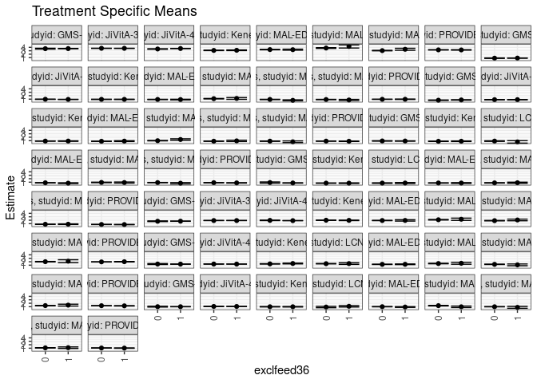

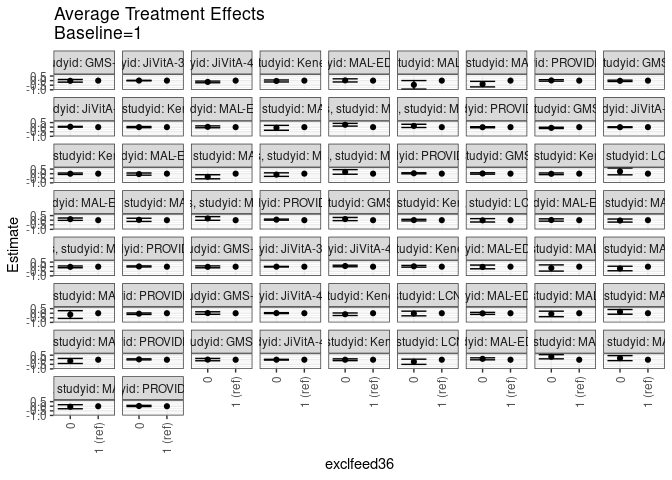

[figure not shown]

## Results Table

### Parameter: TSM

| agecat | studyid | country | intervention_level | baseline_level | estimate | ci_lower | ci_upper |
| --- | --- | --- | --- | --- | --- | --- | --- |
| 0-3 months | GMS-Nepal | NEPAL | 1 | NA | 3.6261393 | 3.5682771 | 3.6840015 |
| 0-3 months | GMS-Nepal | NEPAL | 0 | NA | 3.6036317 | 3.4739435 | 3.7333198 |
| 0-3 months | JiVitA-3 | BANGLADESH | 1 | NA | 3.7032442 | 3.6891208 | 3.7173676 |
| 0-3 months | JiVitA-3 | BANGLADESH | 0 | NA | 3.7104051 | 3.6852349 | 3.7355753 |
| 0-3 months | JiVitA-4 | BANGLADESH | 1 | NA | 3.6507858 | 3.6173992 | 3.6841724 |
| 0-3 months | JiVitA-4 | BANGLADESH | 0 | NA | 3.5095123 | 3.4246008 | 3.5944238 |
| 0-3 months | Keneba | GAMBIA | 1 | NA | 3.1386112 | 3.0480528 | 3.2291695 |
| 0-3 months | Keneba | GAMBIA | 0 | NA | 3.1010537 | 3.0401110 | 3.1619963 |
| 0-3 months | MAL-ED | BANGLADESH | 1 | NA | 3.3120354 | 3.1567374 | 3.4673334 |
| 0-3 months | MAL-ED | BANGLADESH | 0 | NA | 3.3386175 | 3.2665808 | 3.4106541 |
| 0-3 months | MAL-ED | BRAZIL | 1 | NA | 4.2459722 | 3.7916926 | 4.7002519 |
| 0-3 months | MAL-ED | BRAZIL | 0 | NA | 3.7865574 | 3.6750596 | 3.8980552 |
| 0-3 months | MAL-ED | PERU | 1 | NA | 3.4234571 | 3.1291622 | 3.7177520 |
| 0-3 months | MAL-ED | PERU | 0 | NA | 3.0417843 | 2.9741800 | 3.1093886 |
| 0-3 months | PROVIDE | BANGLADESH | 1 | NA | 3.2397936 | 3.1742078 | 3.3053795 |
| 0-3 months | PROVIDE | BANGLADESH | 0 | NA | 3.2594767 | 3.2153456 | 3.3036078 |
| 3-6 months | GMS-Nepal | NEPAL | 1 | NA | 1.7222587 | 1.6786049 | 1.7659125 |
| 3-6 months | GMS-Nepal | NEPAL | 0 | NA | 1.7068447 | 1.6124654 | 1.8012239 |
| 3-6 months | JiVitA-3 | BANGLADESH | 1 | NA | 1.9102748 | 1.8940726 | 1.9264770 |
| 3-6 months | JiVitA-3 | BANGLADESH | 0 | NA | 1.9106347 | 1.8830467 | 1.9382228 |
| 3-6 months | JiVitA-4 | BANGLADESH | 1 | NA | 1.8831613 | 1.8500741 | 1.9162485 |
| 3-6 months | JiVitA-4 | BANGLADESH | 0 | NA | 1.9573701 | 1.8809729 | 2.0337673 |
| 3-6 months | Keneba | GAMBIA | 1 | NA | 1.9604661 | 1.8831867 | 2.0377455 |
| 3-6 months | Keneba | GAMBIA | 0 | NA | 2.0022803 | 1.9526977 | 2.0518629 |
| 3-6 months | MAL-ED | BANGLADESH | 1 | NA | 1.9442823 | 1.7502021 | 2.1383624 |
| 3-6 months | MAL-ED | BANGLADESH | 0 | NA | 1.9190714 | 1.8667233 | 1.9714196 |
| 3-6 months | MAL-ED | BRAZIL | 1 | NA | 2.2815318 | 1.9534135 | 2.6096502 |
| 3-6 months | MAL-ED | BRAZIL | 0 | NA | 2.1397423 | 2.0578193 | 2.2216653 |
| 3-6 months | MAL-ED | INDIA | 1 | NA | 2.0750209 | 1.8360347 | 2.3140071 |
| 3-6 months | MAL-ED | INDIA | 0 | NA | 1.8770379 | 1.8121355 | 1.9419403 |

[output cut: 100 more lines]

### Parameter: E(Y)

| agecat | studyid | country | intervention_level | baseline_level | estimate | ci_lower | ci_upper |
| --- | --- | --- | --- | --- | --- | --- | --- |
| 0-3 months | GMS-Nepal | NEPAL | NA | NA | 3.6173812 | 3.5643204 | 3.6704421 |
| 0-3 months | JiVitA-3 | BANGLADESH | NA | NA | 3.7049234 | 3.6917779 | 3.7180688 |
| 0-3 months | JiVitA-4 | BANGLADESH | NA | NA | 3.6272120 | 3.5957777 | 3.6586463 |
| 0-3 months | Keneba | GAMBIA | NA | NA | 3.1117460 | 3.0607980 | 3.1626940 |
| 0-3 months | MAL-ED | BANGLADESH | NA | NA | 3.3402171 | 3.2743239 | 3.4061103 |
| 0-3 months | MAL-ED | BRAZIL | NA | NA | 3.8085653 | 3.6991781 | 3.9179525 |
| 0-3 months | MAL-ED | PERU | NA | NA | 3.0490404 | 2.9824173 | 3.1156636 |
| 0-3 months | PROVIDE | BANGLADESH | NA | NA | 3.2568758 | 3.2199850 | 3.2937666 |
| 3-6 months | GMS-Nepal | NEPAL | NA | NA | 1.7085606 | 1.6688133 | 1.7483079 |
| 3-6 months | JiVitA-3 | BANGLADESH | NA | NA | 1.9103432 | 1.8959278 | 1.9247587 |
| 3-6 months | JiVitA-4 | BANGLADESH | NA | NA | 1.8946008 | 1.8642204 | 1.9249811 |
| 3-6 months | Keneba | GAMBIA | NA | NA | 1.9917249 | 1.9499823 | 2.0334676 |
| 3-6 months | MAL-ED | BANGLADESH | NA | NA | 1.9261033 | 1.8757410 | 1.9764655 |
| 3-6 months | MAL-ED | BRAZIL | NA | NA | 2.1460815 | 2.0668679 | 2.2252951 |
| 3-6 months | MAL-ED | INDIA | NA | NA | 1.8848530 | 1.8216037 | 1.9481024 |
| 3-6 months | MAL-ED | PERU | NA | NA | 2.0156821 | 1.9494666 | 2.0818976 |
| 3-6 months | PROVIDE | BANGLADESH | NA | NA | 1.9680194 | 1.9343778 | 2.0016611 |
| 6-9 months | GMS-Nepal | NEPAL | NA | NA | 1.3144775 | 1.2731267 | 1.3558284 |
| 6-9 months | JiVitA-4 | BANGLADESH | NA | NA | 1.3252108 | 1.3036943 | 1.3467274 |
| 6-9 months | Keneba | GAMBIA | NA | NA | 1.4086727 | 1.3529368 | 1.4644086 |
| 6-9 months | LCNI-5 | MALAWI | NA | NA | 1.4372604 | 1.3755150 | 1.4990057 |
| 6-9 months | MAL-ED | BANGLADESH | NA | NA | 1.2480451 | 1.2083209 | 1.2877694 |
| 6-9 months | MAL-ED | BRAZIL | NA | NA | 1.4831159 | 1.4026580 | 1.5635738 |
| 6-9 months | MAL-ED | INDIA | NA | NA | 1.2403346 | 1.1889010 | 1.2917682 |
| 6-9 months | MAL-ED | PERU | NA | NA | 1.3199965 | 1.2656612 | 1.3743319 |
| 6-9 months | PROVIDE | BANGLADESH | NA | NA | 1.2824185 | 1.2571827 | 1.3076542 |
| 9-12 months | GMS-Nepal | NEPAL | NA | NA | 0.9984152 | 0.9640726 | 1.0327578 |
| 9-12 months | JiVitA-4 | BANGLADESH | NA | NA | 1.0692570 | 1.0496985 | 1.0888155 |
| 9-12 months | Keneba | GAMBIA | NA | NA | 0.9859004 | 0.9415938 | 1.0302070 |
| 9-12 months | LCNI-5 | MALAWI | NA | NA | 0.9706344 | 0.8246089 | 1.1166600 |
| 9-12 months | MAL-ED | BANGLADESH | NA | NA | 0.9896446 | 0.9509752 | 1.0283140 |
| 9-12 months | MAL-ED | BRAZIL | NA | NA | 1.2982559 | 1.2240694 | 1.3724425 |
| 9-12 months | MAL-ED | INDIA | NA | NA | 0.9798686 | 0.9411954 | 1.0185419 |
| 9-12 months | MAL-ED | PERU | NA | NA | 1.0985124 | 1.0475959 | 1.1494289 |
| 9-12 months | PROVIDE | BANGLADESH | NA | NA | 1.0503544 | 1.0233548 | 1.0773539 |
| 12-15 months | GMS-Nepal | NEPAL | NA | NA | 0.8702474 | 0.8441404 | 0.8963544 |
| 12-15 months | JiVitA-4 | BANGLADESH | NA | NA | 0.9373418 | 0.9196982 | 0.9549854 |
| 12-15 months | Keneba | GAMBIA | NA | NA | 0.9411780 | 0.9094953 | 0.9728606 |
| 12-15 months | MAL-ED | BANGLADESH | NA | NA | 0.9141004 | 0.8737459 | 0.9544550 |
| 12-15 months | MAL-ED | BRAZIL | NA | NA | 1.1421774 | 1.0831447 | 1.2012100 |
| 12-15 months | MAL-ED | INDIA | NA | NA | 0.9075845 | 0.8681682 | 0.9470009 |
| 12-15 months | MAL-ED | PERU | NA | NA | 0.8917280 | 0.8454370 | 0.9380189 |
| 12-15 months | PROVIDE | BANGLADESH | NA | NA | 0.9598579 | 0.9336493 | 0.9860665 |
| 15-18 months | GMS-Nepal | NEPAL | NA | NA | 0.7596809 | 0.7265174 | 0.7928444 |
| 15-18 months | JiVitA-4 | BANGLADESH | NA | NA | 0.8576466 | 0.8394619 | 0.8758313 |
| 15-18 months | Keneba | GAMBIA | NA | NA | 0.8768325 | 0.8429175 | 0.9107475 |
| 15-18 months | MAL-ED | BANGLADESH | NA | NA | 0.8241226 | 0.7871907 | 0.8610544 |
| 15-18 months | MAL-ED | BRAZIL | NA | NA | 1.0021114 | 0.9429996 | 1.0612232 |
| 15-18 months | MAL-ED | INDIA | NA | NA | 0.8476806 | 0.8113849 | 0.8839763 |
| 15-18 months | MAL-ED | PERU | NA | NA | 0.8534307 | 0.8111406 | 0.8957208 |
| 15-18 months | PROVIDE | BANGLADESH | NA | NA | 0.8562969 | 0.8321689 | 0.8804249 |
| 18-21 months | GMS-Nepal | NEPAL | NA | NA | 0.9045343 | 0.8683581 | 0.9407104 |
| 18-21 months | Keneba | GAMBIA | NA | NA | 0.8164462 | 0.7785749 | 0.8543176 |
| 18-21 months | LCNI-5 | MALAWI | NA | NA | 0.8419773 | 0.7481346 | 0.9358201 |
| 18-21 months | MAL-ED | BANGLADESH | NA | NA | 0.8133847 | 0.7790076 | 0.8477619 |
| 18-21 months | MAL-ED | BRAZIL | NA | NA | 0.9160758 | 0.8452655 | 0.9868862 |
| 18-21 months | MAL-ED | INDIA | NA | NA | 0.8759623 | 0.8406388 | 0.9112858 |
| 18-21 months | PROVIDE | BANGLADESH | NA | NA | 0.8393900 | 0.8153565 | 0.8634234 |
| 21-24 months | GMS-Nepal | NEPAL | NA | NA | 0.7920360 | 0.7445193 | 0.8395527 |
| 21-24 months | Keneba | GAMBIA | NA | NA | 0.7224865 | 0.6857861 | 0.7591869 |
| 21-24 months | LCNI-5 | MALAWI | NA | NA | 0.7342569 | 0.6662316 | 0.8022822 |
| 21-24 months | MAL-ED | BANGLADESH | NA | NA | 0.7694183 | 0.7339448 | 0.8048918 |
| 21-24 months | MAL-ED | BRAZIL | NA | NA | 0.7961519 | 0.7521041 | 0.8401997 |
| 21-24 months | MAL-ED | INDIA | NA | NA | 0.8269217 | 0.7961503 | 0.8576932 |
| 21-24 months | PROVIDE | BANGLADESH | NA | NA | 0.7635979 | 0.7381659 | 0.7890298 |

### Parameter: ATE

| agecat | studyid | country | intervention_level | baseline_level | estimate | ci_lower | ci_upper |
| --- | --- | --- | --- | --- | --- | --- | --- |
| 0-3 months | GMS-Nepal | NEPAL | 1 | 1 | 0.0000000 | 0.0000000 | 0.0000000 |
| 0-3 months | GMS-Nepal | NEPAL | 0 | 1 | -0.0225076 | -0.1647762 | 0.1197610 |
| 0-3 months | JiVitA-3 | BANGLADESH | 1 | 1 | 0.0000000 | 0.0000000 | 0.0000000 |
| 0-3 months | JiVitA-3 | BANGLADESH | 0 | 1 | 0.0071609 | -0.0195297 | 0.0338515 |
| 0-3 months | JiVitA-4 | BANGLADESH | 1 | 1 | 0.0000000 | 0.0000000 | 0.0000000 |
| 0-3 months | JiVitA-4 | BANGLADESH | 0 | 1 | -0.1412735 | -0.2320977 | -0.0504493 |
| 0-3 months | Keneba | GAMBIA | 1 | 1 | 0.0000000 | 0.0000000 | 0.0000000 |
| 0-3 months | Keneba | GAMBIA | 0 | 1 | -0.0375575 | -0.1458211 | 0.0707061 |
| 0-3 months | MAL-ED | BANGLADESH | 1 | 1 | 0.0000000 | 0.0000000 | 0.0000000 |
| 0-3 months | MAL-ED | BANGLADESH | 0 | 1 | 0.0265821 | -0.1441164 | 0.1972806 |
| 0-3 months | MAL-ED | BRAZIL | 1 | 1 | 0.0000000 | 0.0000000 | 0.0000000 |
| 0-3 months | MAL-ED | BRAZIL | 0 | 1 | -0.4594149 | -0.9271773 | 0.0083476 |
| 0-3 months | MAL-ED | PERU | 1 | 1 | 0.0000000 | 0.0000000 | 0.0000000 |
| 0-3 months | MAL-ED | PERU | 0 | 1 | -0.3816728 | -0.6836328 | -0.0797128 |
| 0-3 months | PROVIDE | BANGLADESH | 1 | 1 | 0.0000000 | 0.0000000 | 0.0000000 |
| 0-3 months | PROVIDE | BANGLADESH | 0 | 1 | 0.0196830 | -0.0593192 | 0.0986853 |
| 3-6 months | GMS-Nepal | NEPAL | 1 | 1 | 0.0000000 | 0.0000000 | 0.0000000 |
| 3-6 months | GMS-Nepal | NEPAL | 0 | 1 | -0.0154140 | -0.1199143 | 0.0890863 |
| 3-6 months | JiVitA-3 | BANGLADESH | 1 | 1 | 0.0000000 | 0.0000000 | 0.0000000 |
| 3-6 months | JiVitA-3 | BANGLADESH | 0 | 1 | 0.0003599 | -0.0305560 | 0.0312759 |
| 3-6 months | JiVitA-4 | BANGLADESH | 1 | 1 | 0.0000000 | 0.0000000 | 0.0000000 |
| 3-6 months | JiVitA-4 | BANGLADESH | 0 | 1 | 0.0742088 | -0.0088387 | 0.1572563 |
| 3-6 months | Keneba | GAMBIA | 1 | 1 | 0.0000000 | 0.0000000 | 0.0000000 |
| 3-6 months | Keneba | GAMBIA | 0 | 1 | 0.0418143 | -0.0499056 | 0.1335342 |
| 3-6 months | MAL-ED | BANGLADESH | 1 | 1 | 0.0000000 | 0.0000000 | 0.0000000 |
| 3-6 months | MAL-ED | BANGLADESH | 0 | 1 | -0.0252108 | -0.2286538 | 0.1782322 |
| 3-6 months | MAL-ED | BRAZIL | 1 | 1 | 0.0000000 | 0.0000000 | 0.0000000 |
| 3-6 months | MAL-ED | BRAZIL | 0 | 1 | -0.1417895 | -0.4801932 | 0.1966142 |
| 3-6 months | MAL-ED | INDIA | 1 | 1 | 0.0000000 | 0.0000000 | 0.0000000 |
| 3-6 months | MAL-ED | INDIA | 0 | 1 | -0.1979830 | -0.4456254 | 0.0496593 |

[output cut: 100 more lines]

### Parameter: PAR

| agecat | studyid | country | intervention_level | baseline_level | estimate | ci_lower | ci_upper |
| --- | --- | --- | --- | --- | --- | --- | --- |
| 0-3 months | GMS-Nepal | NEPAL | 1 | NA | -0.0087580 | -0.0372941 | 0.0197781 |
| 0-3 months | JiVitA-3 | BANGLADESH | 1 | NA | 0.0016792 | -0.0042279 | 0.0075863 |
| 0-3 months | JiVitA-4 | BANGLADESH | 1 | NA | -0.0235738 | -0.0390781 | -0.0080695 |
| 0-3 months | Keneba | GAMBIA | 1 | NA | -0.0268652 | -0.1036879 | 0.0499575 |
| 0-3 months | MAL-ED | BANGLADESH | 1 | NA | 0.0281817 | -0.1203208 | 0.1766842 |
| 0-3 months | MAL-ED | BRAZIL | 1 | NA | -0.4374070 | -0.8830117 | 0.0081977 |
| 0-3 months | MAL-ED | PERU | 1 | NA | -0.3744167 | -0.6688953 | -0.0799380 |
| 0-3 months | PROVIDE | BANGLADESH | 1 | NA | 0.0170821 | -0.0420370 | 0.0762013 |
| 3-6 months | GMS-Nepal | NEPAL | 1 | NA | -0.0136981 | -0.0359130 | 0.0085167 |
| 3-6 months | JiVitA-3 | BANGLADESH | 1 | NA | 0.0000685 | -0.0070844 | 0.0072213 |
| 3-6 months | JiVitA-4 | BANGLADESH | 1 | NA | 0.0114395 | -0.0014848 | 0.0243638 |
| 3-6 months | Keneba | GAMBIA | 1 | NA | 0.0312589 | -0.0364387 | 0.0989565 |
| 3-6 months | MAL-ED | BANGLADESH | 1 | NA | -0.0181790 | -0.1967914 | 0.1604334 |
| 3-6 months | MAL-ED | BRAZIL | 1 | NA | -0.1354503 | -0.4553725 | 0.1844719 |
| 3-6 months | MAL-ED | INDIA | 1 | NA | -0.1901679 | -0.4280878 | 0.0477520 |
| 3-6 months | MAL-ED | PERU | 1 | NA | -0.1432705 | -0.5562717 | 0.2697308 |
| 3-6 months | PROVIDE | BANGLADESH | 1 | NA | -0.0397718 | -0.0978228 | 0.0182792 |
| 6-9 months | GMS-Nepal | NEPAL | 1 | NA | 0.0008826 | -0.0257449 | 0.0275100 |
| 6-9 months | JiVitA-4 | BANGLADESH | 1 | NA | 0.0012663 | -0.0092696 | 0.0118023 |
| 6-9 months | Keneba | GAMBIA | 1 | NA | -0.0822683 | -0.1829929 | 0.0184563 |
| 6-9 months | LCNI-5 | MALAWI | 1 | NA | -0.0292270 | -0.2467218 | 0.1882679 |
| 6-9 months | MAL-ED | BANGLADESH | 1 | NA | -0.0141301 | -0.1094088 | 0.0811487 |
| 6-9 months | MAL-ED | BRAZIL | 1 | NA | -0.0713909 | -0.3549860 | 0.2122043 |
| 6-9 months | MAL-ED | INDIA | 1 | NA | 0.1434039 | -0.1026096 | 0.3894174 |
| 6-9 months | MAL-ED | PERU | 1 | NA | -0.1304608 | -0.3990978 | 0.1381761 |
| 6-9 months | PROVIDE | BANGLADESH | 1 | NA | 0.0325923 | -0.0128336 | 0.0780182 |
| 9-12 months | GMS-Nepal | NEPAL | 1 | NA | 0.0017020 | -0.0195376 | 0.0229416 |
| 9-12 months | JiVitA-4 | BANGLADESH | 1 | NA | 0.0007344 | -0.0092156 | 0.0106845 |
| 9-12 months | Keneba | GAMBIA | 1 | NA | 0.0006883 | -0.0662428 | 0.0676193 |
| 9-12 months | LCNI-5 | MALAWI | 1 | NA | -0.1486152 | -0.3508086 | 0.0535782 |
| 9-12 months | MAL-ED | BANGLADESH | 1 | NA | 0.0848402 | -0.0118667 | 0.1815470 |
| 9-12 months | MAL-ED | BRAZIL | 1 | NA | 0.3245633 | 0.1078337 | 0.5412928 |
| 9-12 months | MAL-ED | INDIA | 1 | NA | 0.1695631 | -0.0960756 | 0.4352019 |
| 9-12 months | MAL-ED | PERU | 1 | NA | -0.0506153 | -0.2653605 | 0.1641298 |
| 9-12 months | PROVIDE | BANGLADESH | 1 | NA | 0.0224806 | -0.0257848 | 0.0707460 |
| 12-15 months | GMS-Nepal | NEPAL | 1 | NA | -0.0038583 | -0.0179941 | 0.0102775 |
| 12-15 months | JiVitA-4 | BANGLADESH | 1 | NA | 0.0090594 | -0.0008885 | 0.0190074 |
| 12-15 months | Keneba | GAMBIA | 1 | NA | 0.0020947 | -0.0421518 | 0.0463412 |
| 12-15 months | MAL-ED | BANGLADESH | 1 | NA | 0.0299926 | -0.0601072 | 0.1200924 |
| 12-15 months | MAL-ED | BRAZIL | 1 | NA | -0.0697924 | -0.3203646 | 0.1807798 |
| 12-15 months | MAL-ED | INDIA | 1 | NA | 0.2523161 | 0.1073622 | 0.3972700 |
| 12-15 months | MAL-ED | PERU | 1 | NA | 0.1336334 | -0.0373524 | 0.3046192 |
| 12-15 months | PROVIDE | BANGLADESH | 1 | NA | -0.0059839 | -0.0478756 | 0.0359077 |
| 15-18 months | GMS-Nepal | NEPAL | 1 | NA | -0.0148298 | -0.0283668 | -0.0012928 |
| 15-18 months | JiVitA-4 | BANGLADESH | 1 | NA | 0.0011852 | -0.0080037 | 0.0103741 |
| 15-18 months | Keneba | GAMBIA | 1 | NA | -0.0067237 | -0.0610572 | 0.0476099 |
| 15-18 months | MAL-ED | BANGLADESH | 1 | NA | -0.0427452 | -0.1489307 | 0.0634403 |
| 15-18 months | MAL-ED | BRAZIL | 1 | NA | -0.3318963 | -0.5408101 | -0.1229825 |
| 15-18 months | MAL-ED | INDIA | 1 | NA | -0.0977056 | -0.2842204 | 0.0888092 |
| 15-18 months | MAL-ED | PERU | 1 | NA | 0.1838263 | -0.0598294 | 0.4274820 |
| 15-18 months | PROVIDE | BANGLADESH | 1 | NA | 0.0321750 | -0.0111117 | 0.0754617 |
| 18-21 months | GMS-Nepal | NEPAL | 1 | NA | 0.0050235 | -0.0085899 | 0.0186370 |
| 18-21 months | Keneba | GAMBIA | 1 | NA | -0.0138555 | -0.0775505 | 0.0498395 |
| 18-21 months | LCNI-5 | MALAWI | 1 | NA | 0.2068370 | -0.0973238 | 0.5109978 |
| 18-21 months | MAL-ED | BANGLADESH | 1 | NA | 0.1049577 | -0.0105650 | 0.2204805 |
| 18-21 months | MAL-ED | BRAZIL | 1 | NA | 0.0294507 | -0.1335457 | 0.1924471 |
| 18-21 months | MAL-ED | INDIA | 1 | NA | 0.1799418 | -0.0125521 | 0.3724358 |
| 18-21 months | PROVIDE | BANGLADESH | 1 | NA | 0.0477126 | 0.0052108 | 0.0902145 |
| 21-24 months | GMS-Nepal | NEPAL | 1 | NA | 0.0234307 | -0.0054143 | 0.0522757 |
| 21-24 months | Keneba | GAMBIA | 1 | NA | 0.0081882 | -0.0536202 | 0.0699965 |
| 21-24 months | LCNI-5 | MALAWI | 1 | NA | -0.0168244 | -0.1690828 | 0.1354339 |
| 21-24 months | MAL-ED | BANGLADESH | 1 | NA | 0.0211862 | -0.0902602 | 0.1326327 |
| 21-24 months | MAL-ED | BRAZIL | 1 | NA | -0.0366927 | -0.1926183 | 0.1192330 |
| 21-24 months | MAL-ED | INDIA | 1 | NA | -0.0165759 | -0.1090840 | 0.0759322 |
| 21-24 months | PROVIDE | BANGLADESH | 1 | NA | 0.0203875 | -0.0234563 | 0.0642313 |